# Titanic survival: ticket/cabin context, party structure, gender×age, and at-boarding policy drivers

Author

CLI Copilot

# Setup

```r
# Helper: install packages if missing
pkgs <- c(
  "tidyverse", "janitor", "broom", "viridis", "mgcv", "ranger", "knitr", "pROC"
)
inst <- pkgs[!pkgs %in% rownames(installed.packages())]
if (length(inst) > 0) install.packages(inst, repos = "https://cloud.r-project.org")

library(tidyverse)
library(janitor)
library(broom)
library(viridis)
library(mgcv)
library(ranger)
library(knitr)

# ggplot design: minimalist theme, viridis palette, bottom legend
theme_set(theme_minimal(base_size = 12))
update_geom_defaults("point", list(size = 2, alpha = 0.8))
update_geom_defaults("line", list(size = 0.9))

# Paths
train_path <- file.path("..", "data", "train.csv")

# Utility: read CSV
read_train <- function() {
  read_csv(train_path, show_col_types = FALSE) |> clean_names()
}

# Utility: factor ordering
ordered_deck <- function(x) {
  lvls <- c("A","B","C","D","E","F","G","T","Unknown")
  x <- fct_na_value_to_level(x, level = "Unknown")
  fct_other(x, keep = lvls) |> fct_relevel(lvls)
}
```

# Data and feature engineering

Text: We load Titanic training data and engineer variables reflecting ticket/cabin context and travel party structure. We infer group size by ticket (co-travelers sharing a ticket), family size from SibSp and Parch, deck from the first letter of Cabin, and derive additional at-boarding features such as title and ticket prefix.

```r
raw <- read_train()

# Basic cleaning and engineered fields

engineered <- raw |>
  mutate(
    survived_f = factor(if_else(survived == 1, "Yes", "No"), levels = c("No","Yes")),
    sex = factor(sex),
    embarked = factor(embarked, levels = c("C","Q","S")),
    family_size = sib_sp + parch + 1L,
    ticket_clean = str_squish(ticket),
    ticket_prefix = str_extract(ticket_clean, "^[A-Za-z\\./]+") |> str_replace_all("[\\n\\./ ]", "") |> na_if("") |> replace_na("None"),
    cabin_first = str_extract(coalesce(cabin, ""), "^[A-Za-z]") |> na_if("") |> replace_na("Unknown"),
    deck = ordered_deck(cabin_first),
    cabin_known = factor(if_else(is.na(cabin) | cabin == "", "No", "Yes"), levels = c("No","Yes")),
    title = str_extract(name, ",[[:space:]]*([^\\.]+)\\.") |> str_trim() |>
      fct_collapse(Mr = c("Mr"), Mrs = c("Mrs"), Miss = c("Miss", "Mlle"),
                   Master = c("Master"), Dr = c("Dr"),
                   Officer = c("Col","Major","Capt","Rev","Don","Jonkheer"),
                   Royalty = c("Sir","Lady","the Countess","Dona"),
                   Other = c("Mme"))
  ) |>
  group_by(ticket_clean) |>
  mutate(group_size = n()) |>
  ungroup() |>
  mutate(
    # Age imputation for modeling only (kept separate column)
    age_imp = if_else(is.na(age),
                      ave(age, interaction(pclass, sex), FUN = function(x) median(x, na.rm = TRUE))[row_number()],
                      age),
    fare_imp = if_else(is.na(fare), median(fare, na.rm = TRUE), fare)
  )

# Quick overview
engineered |>
  select(survived, pclass, sex, age, age_imp, sib_sp, parch, family_size, group_size, embarked, fare, deck, cabin_known, ticket_prefix, title) |>
  head() |>
  kable()
```

| survived | pclass | sex | age | age_imp | sib_sp | parch | family_size | group_size | embarked | fare | deck | cabin_known | ticket_prefix | title |
| --- | --- | --- | --- | --- | --- | --- | --- | --- | --- | --- | --- | --- | --- | --- |
| 0 | 3 | male | 22 | 22 | 1 | 0 | 2 | 1 | S | 7.2500 | Unknown | No | A | , Mr. |
| 1 | 1 | female | 38 | 38 | 1 | 0 | 2 | 1 | C | 71.2833 | C | Yes | PC | , Mrs. |
| 1 | 3 | female | 26 | 26 | 0 | 0 | 1 | 1 | S | 7.9250 | Unknown | No | STONO | , Miss. |
| 1 | 1 | female | 35 | 35 | 1 | 0 | 2 | 2 | S | 53.1000 | C | Yes | None | , Mrs. |
| 0 | 3 | male | 35 | 35 | 0 | 0 | 1 | 1 | S | 8.0500 | Unknown | No | None | , Mr. |
| 0 | 3 | male | NA | 25 | 0 | 0 | 1 | 1 | Q | 8.4583 | Unknown | No | None | , Mr. |

# Q1. Ticket/cabin context and travel party structure → survival, with mediators

Text: We test how ticket/cabin context (Pclass, cabin_known, deck) and party structure (family_size, group_size) relate to survival. We examine whether deck, group size, and embarkation act as mediators by comparing sequential logistic models and inspecting coefficient attenuation when mediators are added.

```r
# Model A: baseline (ticket/cabin + party structure without mediators)
modA <- glm(survived_f ~ pclass + sex + family_size + group_size + pclass:group_size + cabin_known,
            data = engineered, family = binomial)

# Model B: add potential mediators (deck, embarked)
modB <- glm(survived_f ~ pclass + sex + family_size + group_size + pclass:group_size + cabin_known + deck + embarked,
            data = engineered, family = binomial)

# Compare coefficients and fit
compare_tbl <- bind_rows(
  tidy(modA) |> mutate(model = "A: baseline"),
  tidy(modB) |> mutate(model = "B: + mediators")
) |> mutate(or = exp(estimate),
            conf_low = exp(estimate - 1.96*std.error),
            conf_high = exp(estimate + 1.96*std.error))

kable(compare_tbl, digits = 3)
```

| term | estimate | std.error | statistic | p.value | model | or | conf_low | conf_high |
| --- | --- | --- | --- | --- | --- | --- | --- | --- |
| (Intercept) | 2.233 | 0.612 | 3.649 | 0.000 | A: baseline | 9.324 | 2.810 | 30.934 |
| pclass | -0.449 | 0.217 | -2.067 | 0.039 | A: baseline | 0.638 | 0.417 | 0.977 |
| sexmale | -2.776 | 0.197 | -14.059 | 0.000 | A: baseline | 0.062 | 0.042 | 0.092 |
| family_size | -0.196 | 0.093 | -2.107 | 0.035 | A: baseline | 0.822 | 0.685 | 0.986 |
| group_size | 0.436 | 0.261 | 1.667 | 0.096 | A: baseline | 1.546 | 0.926 | 2.580 |
| cabin_knownYes | 0.697 | 0.287 | 2.426 | 0.015 | A: baseline | 2.007 | 1.143 | 3.524 |
| pclass:group_size | -0.140 | 0.097 | -1.445 | 0.148 | A: baseline | 0.869 | 0.719 | 1.051 |
| (Intercept) | 2.666 | 0.669 | 3.983 | 0.000 | B: + mediators | 14.381 | 3.874 | 53.394 |
| pclass | -0.471 | 0.232 | -2.028 | 0.043 | B: + mediators | 0.624 | 0.396 | 0.984 |
| sexmale | -2.770 | 0.203 | -13.654 | 0.000 | B: + mediators | 0.063 | 0.042 | 0.093 |
| family_size | -0.177 | 0.095 | -1.859 | 0.063 | B: + mediators | 0.838 | 0.695 | 1.010 |
| group_size | 0.484 | 0.275 | 1.759 | 0.079 | B: + mediators | 1.623 | 0.946 | 2.784 |
| cabin_knownYes | 0.448 | 0.613 | 0.731 | 0.465 | B: + mediators | 1.565 | 0.471 | 5.203 |
| deckB | 0.029 | 0.687 | 0.043 | 0.966 | B: + mediators | 1.030 | 0.268 | 3.959 |
| deckC | -0.475 | 0.653 | -0.727 | 0.467 | B: + mediators | 0.622 | 0.173 | 2.238 |
| deckD | 0.465 | 0.726 | 0.640 | 0.522 | B: + mediators | 1.592 | 0.384 | 6.610 |
| deckE | 0.910 | 0.721 | 1.262 | 0.207 | B: + mediators | 2.485 | 0.604 | 10.215 |
| deckF | 1.141 | 0.903 | 1.263 | 0.207 | B: + mediators | 3.130 | 0.533 | 18.378 |
| deckG | -0.703 | 1.197 | -0.587 | 0.557 | B: + mediators | 0.495 | 0.047 | 5.172 |
| deckT | -13.052 | 535.411 | -0.024 | 0.981 | B: + mediators | 0.000 | 0.000 | Inf |
| deckUnknown | NA | NA | NA | NA | B: + mediators | NA | NA | NA |
| embarkedQ | -0.291 | 0.375 | -0.777 | 0.437 | B: + mediators | 0.747 | 0.359 | 1.558 |
| embarkedS | -0.537 | 0.233 | -2.302 | 0.021 | B: + mediators | 0.584 | 0.370 | 0.923 |
| pclass:group_size | -0.157 | 0.102 | -1.536 | 0.125 | B: + mediators | 0.855 | 0.699 | 1.044 |

```r
fit_tbl <- tibble(
  model = c("A: baseline", "+ mediators"),
  AIC = c(AIC(modA), AIC(modB)),
  McFadden_R2 = c(1 - logLik(modA)/logLik(update(modA, . ~ 1)),
                  1 - logLik(modB)/logLik(update(modB, . ~ 1))) |> as.numeric()
)

kable(fit_tbl, digits = 3)
```

| model | AIC | McFadden_R2 |
| --- | --- | --- |
| A: baseline | 824.974 | 0.317 |
| + mediators | 827.620 | 0.330 |

## Visualizing joint effects and mediator pathways

Text: We visualize predicted survival across group size and ticket class, and show how predictions shift when mediators are included.

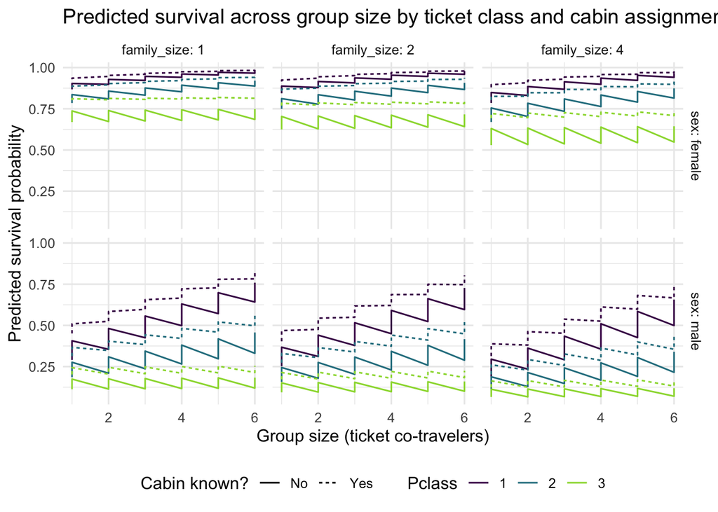

```r
# Create grid for predictions
newdat <- expand_grid(
  pclass = 1:3,
  sex = factor(c("female","male"), levels = c("female","male")),
  family_size = c(1,2,4),
  group_size = 1:6,
  cabin_known = factor(c("No","Yes"), levels = c("No","Yes")),
  deck = factor(c("Unknown","A","B","C","D","E","F"), levels = levels(engineered$deck)),
  embarked = factor(c("C","Q","S"), levels = levels(engineered$embarked))
)

predA <- newdat |>
  mutate(prob = plogis(predict(modA, newdat, type = "link")), model = "A: baseline")

predB <- newdat |>
  mutate(prob = plogis(predict(modB, newdat, type = "link")), model = "B: + mediators")

preds <- bind_rows(predA, predB)

# Aggregate over mediator levels to compare average effects
agg <- preds |>
  group_by(model, pclass, sex, family_size, group_size, cabin_known) |>
  summarize(prob = mean(prob), .groups = "drop")

agg |>
  ggplot(aes(group_size, prob, color = factor(pclass), linetype = cabin_known)) +
  geom_line() +
  facet_grid(sex ~ family_size, labeller = label_both) +
  scale_color_viridis(discrete = TRUE, end = 0.85, option = "D") +
  labs(title = "Predicted survival across group size by ticket class and cabin assignment",
       x = "Group size (ticket co-travelers)", y = "Predicted survival probability",
       color = "Pclass", linetype = "Cabin known?" ) +
  theme(legend.position = "bottom")
```

# Q2. Gender × age (nonlinear): “women and children first” profile

Text: We fit a GAM with smooths of age by gender to capture nonlinear survival-age profiles and test whether the gender gap varies across the lifespan.

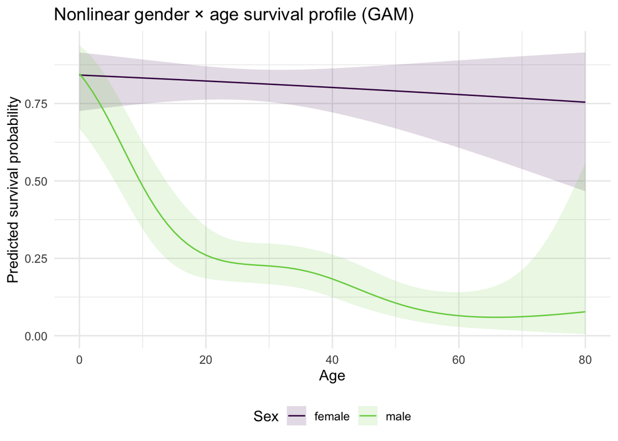

```r
# Use complete cases on age for GAM; small N so we keep it simple
cc <- engineered |> filter(!is.na(age)) |> mutate(survived_bin = as.integer(survived_f == "Yes"))

m_gam <- gam(survived_bin ~ sex + s(age, by = sex, k = 6) + pclass,
             data = cc, family = binomial(link = "logit"), method = "REML")

# Prediction grid for smooths
new_age <- expand_grid(
  age = seq(0, 80, by = 1),
  sex = factor(c("female","male"), levels = c("female","male")),
  pclass = 2 # hold typical class fixed for visualization
)

pred_gam <- predict(m_gam, newdata = new_age, type = "link", se.fit = TRUE)
new_age <- new_age |>
  mutate(
    fit = pred_gam$fit,
    se = pred_gam$se.fit,
    prob = plogis(fit),
    lo = plogis(fit - 1.96*se),
    hi = plogis(fit + 1.96*se)
  )

new_age |>
  ggplot(aes(age, prob, color = sex, fill = sex)) +
  geom_ribbon(aes(ymin = lo, ymax = hi), alpha = 0.15, color = NA) +
  geom_line() +
  scale_color_viridis(discrete = TRUE, end = 0.8) +
  scale_fill_viridis(discrete = TRUE, end = 0.8) +
  labs(title = "Nonlinear gender × age survival profile (GAM)",
       x = "Age", y = "Predicted survival probability", color = "Sex", fill = "Sex") +
  theme(legend.position = "bottom")
```

```r
# Brief significance summary
kable(tidy(m_gam), digits = 3)
```

| term | edf | ref.df | statistic | p.value |
| --- | --- | --- | --- | --- |
| s(age):sexfemale | 1.000 | 1.001 | 0.350 | 0.554 |
| s(age):sexmale | 3.582 | 4.213 | 43.186 | 0.000 |

# Q3. At-boarding predictive features and operational policy

Text: We restrict to information plausibly known at or before boarding (exclude cabin deck specifics if uncertain). We train a fast random forest (ranger) and examine feature importance, then translate top predictors into operational safety guidance.

```r
# Features known pre-boarding: pclass, sex, age (or est.), sib_sp, parch, fare, embarked, ticket_prefix, group_size, family_size, title
model_df <- engineered |>
  mutate(survived_bin = as.integer(survived_f == "Yes")) |>
  select(survived_bin, pclass, sex, age_imp, sib_sp, parch, fare_imp, embarked, ticket_prefix, group_size, family_size, title)

set.seed(123)
idx <- sample.int(nrow(model_df), floor(0.75 * nrow(model_df)))
train_df <- model_df[idx,]
valid_df <- model_df[-idx,]

rf <- ranger(
  survived_bin ~ ., data = train_df, probability = TRUE,
  num.trees = 1000, mtry = 4, min.node.size = 5, importance = "impurity"
)

pred <- predict(rf, data = valid_df)$predictions[,2]
roc_auc <- pROC::auc(response = valid_df$survived_bin, predictor = pred)

imp <- as_tibble(rf$variable.importance, rownames = "feature") |>
  arrange(desc(value)) |>
  rename(importance = value)

kable(tibble(Metric = "ROC AUC (holdout)", Value = as.numeric(roc_auc)), digits = 3)
```

| Metric | Value |
| --- | --- |
| ROC AUC (holdout) | 0.89 |

```r
imp |> head(12) |> kable(digits = 3)
```

| feature | importance |
| --- | --- |
| sex | 67.781 |
| fare_imp | 44.741 |
| age_imp | 40.678 |
| title | 32.539 |
| pclass | 19.510 |
| group_size | 15.255 |
| family_size | 11.677 |
| ticket_prefix | 11.163 |
| embarked | 8.036 |
| sib_sp | 7.346 |
| parch | 4.634 |

## Policy implications (based on drivers)

Text: Based on the most predictive features, we propose actionable pre-incident policies:

- If group_size and family_size strongly predict survival, ensure muster and signage accommodate intact parties; assign crew to guide larger parties from lower classes.
- If sex and age dominate, reinforce “women and children first” drills with targeted crew allocation at congested embarkation points (Embarked S vs C/Q differences may proxy crowding/route).
- If pclass and fare (SES proxies) drive disparity, implement cross-deck access controls and equitable lifeboat allocation drills.
- Use ticket_prefix/group_size to pre-map parties to adjacent muster stations; flag unusually large tickets for extra assistance.

We recommend validating these policies with regular drills and monitoring throughput bottlenecks by embarkation port.